# Table of Contents

**Kernel Author:**  
[Bhishan Poudel, Data Scientist, Ph.D Astrophysics](https://bhishanpdl.github.io/) .

# Data Description

> The datasets contains transactions made by credit cards in September 2013 by european cardholders.

> This dataset presents transactions that occurred in two days, where we have 492 frauds out of 284,807 transactions.

> The dataset is highly unbalanced, the positive class (frauds) account for 0.172% of all transactions.

> It contains only numerical input variables which are the result of a PCA transformation.

> Unfortunately, due to confidentiality issues, we cannot provide the original features and more background information about the data.

> Features V1, V2, ... V28 are the principal components obtained with PCA, the only features which have not been transformed with PCA are 'Time' and 'Amount'.

> Feature 'Time' contains the seconds elapsed between each transaction and the first transaction in the dataset. The feature 'Amount' is the transaction Amount, this feature can be used for example-dependant cost-senstive learning.

> Feature 'Class' is the response variable and it takes value 1 in case of fraud and 0 otherwise.

# Business Problem

Remember that `Recall = TP / (TP + FN)`. In case of fraud detection, classifying a fraud as non-fraud (FN) is more risky so we use the metric `recall` to compare the performances of the models. Higher the recall, better is the model.

Also, we should note that the data is just of two days, we implicitly assume that these two days are represent of the whole trend and reflects the property of the population properly.

The could have been more or less fraudulent transactions in those particular days, but we would not take that into consideration and we generalizes the result. Or, we can say that based on the data from these two days we reached following conclusion and the result is appropriate for the population where the data distribution is similar to that of these two days.

We are more interestd in finding the Fraud cases. i.e. FN (False Negative) cases, predicting fraud as non-fraud is riskier than predicting non-fraud as fraud. So, the suitable metric of model evaluation is RECALL.

In banking, it is always the case that there are a lot of normal transactions, and only few of them are fraudulent. We may train our model with any transformation of the training data, but when testing the model the test set should look like real life, i.e., it has lots of normal cases and very few fraudulent cases.

This means we can train our model using imbalanced or balanced (undersamples or oversampled) but we should test our model on IMBALANCED dataset.

**WARNINGS for Serialization:**  
When using the picked object (serialized object), the machine should have all the same versions of libraries used, such as numpy, pandas, scikit-learn, and all other dependency libraries.  
So, to load the serialized object make sure you have the same conda environment as it was when creating the serialized object.

# Imports

```python
import numpy as np
import pandas as pd
import seaborn as sns
sns.set(color_codes=True)

import matplotlib
import matplotlib.pyplot as plt
%matplotlib inline

import os
import time

# random state
random_state=100
np.random.seed(random_state) # we need this in each cell
np.random.set_state=random_state

# Jupyter notebook settings for pandas
pd.set_option('display.max_columns', 200)
pd.set_option('display.max_rows', 100) # None for all the rows
pd.set_option('display.max_colwidth', 50)

print([(x.__name__,x.__version__) for x in [np, pd,sns,matplotlib]])
```

```
[('numpy', '1.17.1'), ('pandas', '0.25.1'), ('seaborn', '0.9.0'), ('matplotlib', '3.1.1')]
```

```python
%%javascript
IPython.OutputArea.auto_scroll_threshold = 9999;
```

```python
# pyspark
import pyspark
spark = pyspark.sql.SparkSession.builder.appName('bhishan').getOrCreate()
print([(x.__name__,x.__version__) for x in [np, pd, pyspark]])
```

```
[('numpy', '1.17.1'), ('pandas', '0.25.1'), ('pyspark', '2.4.4')]
```

```python
# pyspark sql
from pyspark.sql.functions import col
from pyspark.sql.functions import udf # @udf("integer") def myfunc(x,y): return x - y
from pyspark.sql import functions as F # stddev format_number date_format, dayofyear, when
from pyspark.sql.types import StructField, StringType, IntegerType, FloatType, StructType, DateType
```

```python
# pyspark ml feature
from pyspark.ml.feature import StringIndexer, VectorIndexer
from pyspark.ml.feature import OneHotEncoder,OneHotEncoderEstimator
from pyspark.ml.feature import Bucketizer
from pyspark.ml.feature import VectorAssembler
from pyspark.ml.feature import StandardScaler
from pyspark.ml import Pipeline
```

```python
# classifiers
from pyspark.ml.classification import LogisticRegression
from pyspark.ml.clustering import KMeans
from pyspark.ml.classification import DecisionTreeClassifier
from pyspark.ml.classification import RandomForestClassifier
from pyspark.ml.classification import GBTClassifier
```

```python
# cross validation
from pyspark.ml.tuning import ParamGridBuilder
from pyspark.ml.tuning import CrossValidator
from pyspark.ml.tuning import CrossValidatorModel
```

```python
# model evaluation
from pyspark.ml.evaluation import BinaryClassificationEvaluator
from pyspark.ml.evaluation import MulticlassClassificationEvaluator
from pyspark.ml.evaluation import ClusteringEvaluator
```

# Useful Scripts

```python
def show_method_attributes(method, ncols=7):
    """ Show all the attributes of a given method.
    Example:
    ========
    show_method_attributes(list)
     """
    x = [i for i in dir(method) if i[0]!='_' ]
    x = [i for i in x
         if i not in 'os np pd sys time psycopg2'.split() ]


    return pd.DataFrame(np.array_split(x,ncols)).T.fillna('')
```

```python
df_eval = pd.DataFrame({
    'model_name':[],
    'desc':[],
    'f1':[],
    'weightedPrecision':[],
    'weightedRecall':[],
    'accuracy':[],
    'areaUnderROC':[],
    'areaUnderPR':[]
})

df_eval
```

|  | model_name | desc | f1 | weightedPrecision | weightedRecall | accuracy | areaUnderROC | areaUnderPR |
| --- | --- | --- | --- | --- | --- | --- | --- | --- |

# Load the data

```python
%%bash
# unzip ../data/raw/creditcard.csv.zip -d ../data/raw/
ls ../data/raw
```

```
creditcard.csv
creditcard.csv.zip
```

```python
%%bash
head -3 ../data/raw/creditcard.csv
```

```
"Time","V1","V2","V3","V4","V5","V6","V7","V8","V9","V10","V11","V12","V13","V14","V15","V16","V17","V18","V19","V20","V21","V22","V23","V24","V25","V26","V27","V28","Amount","Class"
0,-1.3598071336738,-0.0727811733098497,2.53634673796914,1.37815522427443,-0.338320769942518,0.462387777762292,0.239598554061257,0.0986979012610507,0.363786969611213,0.0907941719789316,-0.551599533260813,-0.617800855762348,-0.991389847235408,-0.311169353699879,1.46817697209427,-0.470400525259478,0.20…
0,1.19185711131486,0.26615071205963,0.16648011335321,0.448154078460911,0.0600176492822243,-0.0823608088155687,-0.0788029833323113,0.0851016549148104,-0.255425128109186,-0.166974414004614,1.61272666105479,1.06523531137287,0.48909501589608,-0.143772296441519,0.635558093258208,0.463917041022171,-0.1148…
```

```python
%%bash
head -5 ../data/raw/creditcard.csv | cut -d ',' -f 1
tail -5 ../data/raw/creditcard.csv | cut -d ',' -f 1
```

```
"Time"
0
0
1
1
172786
172787
172788
172788
172792
```

```python
df = spark.read.csv('../data/raw/creditcard.csv', header=True, inferSchema=True).cache()
print('nrows = ', df.count(), 'ncols = ', len(df.columns))
df.limit(5).toPandas()
```

```
nrows =  284807 ncols =  31
```

|  | Time | V1 | V2 | V3 | V4 | V5 | V6 | V7 | V8 | V9 | V10 | V11 | V12 | V13 | V14 | V15 | V16 | V17 | V18 | V19 | V20 | V21 | V22 | V23 | V24 | V25 | V26 | V27 | V28 | … |
| --- | --- | --- | --- | --- | --- | --- | --- | --- | --- | --- | --- | --- | --- | --- | --- | --- | --- | --- | --- | --- | --- | --- | --- | --- | --- | --- | --- | --- | --- | --- |
| 0 | 0 | -1.359807 | -0.072781 | 2.536347 | 1.378155 | -0.338321 | 0.462388 | 0.239599 | 0.098698 | 0.363787 | 0.090794 | -0.551600 | -0.617801 | -0.991390 | -0.311169 | 1.468177 | -0.470401 | 0.207971 | 0.025791 | 0.403993 | 0.251412 | -0.018307 | 0.277838 | -0.110474 | 0.066928 | 0.128539 | -0.189115 | 0.133558 | -0.021053 | … |
| 1 | 0 | 1.191857 | 0.266151 | 0.166480 | 0.448154 | 0.060018 | -0.082361 | -0.078803 | 0.085102 | -0.255425 | -0.166974 | 1.612727 | 1.065235 | 0.489095 | -0.143772 | 0.635558 | 0.463917 | -0.114805 | -0.183361 | -0.145783 | -0.069083 | -0.225775 | -0.638672 | 0.101288 | -0.339846 | 0.167170 | 0.125895 | -0.008983 | 0.014724 | … |
| 2 | 1 | -1.358354 | -1.340163 | 1.773209 | 0.379780 | -0.503198 | 1.800499 | 0.791461 | 0.247676 | -1.514654 | 0.207643 | 0.624501 | 0.066084 | 0.717293 | -0.165946 | 2.345865 | -2.890083 | 1.109969 | -0.121359 | -2.261857 | 0.524980 | 0.247998 | 0.771679 | 0.909412 | -0.689281 | -0.327642 | -0.139097 | -0.055353 | -0.059752 | … |
| 3 | 1 | -0.966272 | -0.185226 | 1.792993 | -0.863291 | -0.010309 | 1.247203 | 0.237609 | 0.377436 | -1.387024 | -0.054952 | -0.226487 | 0.178228 | 0.507757 | -0.287924 | -0.631418 | -1.059647 | -0.684093 | 1.965775 | -1.232622 | -0.208038 | -0.108300 | 0.005274 | -0.190321 | -1.175575 | 0.647376 | -0.221929 | 0.062723 | 0.061458 | … |
| 4 | 2 | -1.158233 | 0.877737 | 1.548718 | 0.403034 | -0.407193 | 0.095921 | 0.592941 | -0.270533 | 0.817739 | 0.753074 | -0.822843 | 0.538196 | 1.345852 | -1.119670 | 0.175121 | -0.451449 | -0.237033 | -0.038195 | 0.803487 | 0.408542 | -0.009431 | 0.798278 | -0.137458 | 0.141267 | -0.206010 | 0.502292 | 0.219422 | 0.215153 | … |

```python
df.printSchema()
```

```
root
 |-- Time: decimal(10,0) (nullable = true)
 |-- V1: double (nullable = true)
 |-- V2: double (nullable = true)
 |-- V3: double (nullable = true)
 |-- V4: double (nullable = true)
 |-- V5: double (nullable = true)
 |-- V6: double (nullable = true)
 |-- V7: double (nullable = true)
 |-- V8: double (nullable = true)
 |-- V9: double (nullable = true)
 |-- V10: double (nullable = true)
 |-- V11: double (nullable = true)
 |-- V12: double (nullable = true)
 |-- V13: double (nullable = true)
 |-- V14: double (nullable = true)
 |-- V15: double (nullable = true)
 |-- V16: double (nullable = true)
 |-- V17: double (nullable = true)
 |-- V18: double (nullable = true)
 |-- V19: double (nullable = true)
 |-- V20: double (nullable = true)
 |-- V21: double (nullable = true)
 |-- V22: double (nullable = true)
 |-- V23: double (nullable = true)
 |-- V24: double (nullable = true)
 |-- V25: double (nullable = true)
 |-- V26: double (nullable = true)
 |-- V27: double (nullable = true)
 |-- V28: double (nullable = true)
 |-- Amount: double (nullable = true)
 |-- Class: integer (nullable = true)
```

```python
print(df.columns)
```

```
['Time', 'V1', 'V2', 'V3', 'V4', 'V5', 'V6', 'V7', 'V8', 'V9', 'V10', 'V11', 'V12', 'V13', 'V14', 'V15', 'V16', 'V17', 'V18', 'V19', 'V20', 'V21', 'V22', 'V23', 'V24', 'V25', 'V26', 'V27', 'V28', 'Amount', 'Class']
```

# EDA

```python
feat = 'Amount'
target = 'Class'
df.select([feat,target]).show(5)
```

```
+------+-----+
|Amount|Class|
+------+-----+
|149.62|    0|
|  2.69|    0|
|378.66|    0|
| 123.5|    0|
| 69.99|    0|
+------+-----+
only showing top 5 rows
```

```python
df.select(F.mean(feat), F.max(feat)).show()
```

```
+----------------+-----------+
|     avg(Amount)|max(Amount)|
+----------------+-----------+
|88.3496192509521|   25691.16|
+----------------+-----------+
```

```python
df.select([x(df[feat])
           for x in [F.max, F.min ]]).show()
```

```
+-----------+-----------+
|max(Amount)|min(Amount)|
+-----------+-----------+
|   25691.16|        0.0|
+-----------+-----------+
```

```python
df.select(target).distinct().show()
```

```
+-----+
|Class|
+-----+
|    1|
|    0|
+-----+
```

```python
df.groupBy(target).agg(F.max(feat)).show()
```

```
+-----+-----------+
|Class|max(Amount)|
+-----+-----------+
|    1|    2125.87|
|    0|   25691.16|
+-----+-----------+
```

```python
df.filter(df['Amount']>10000).agg({'Class': 'count'}).show()
```

```
+------------+
|count(Class)|
+------------+
|           7|
+------------+
```

```python
df.select('Time', 'Amount').filter(df['Class'].isin(0,1)).show(2)
```

```
+----+------+
|Time|Amount|
+----+------+
|   0|149.62|
|   0|  2.69|
+----+------+
only showing top 2 rows
```

```python
grp =  df.groupBy("Class").count().sort("Class", ascending=False)
```

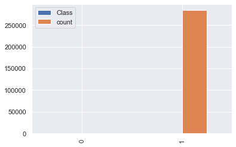

```python
grp.toPandas().plot.bar()
```

```python
df.drop('Time','Amount','Class').describe().toPandas().set_index('summary').astype(float).round(3)
```

| summary | V1 | V2 | V3 | V4 | V5 | V6 | V7 | V8 | V9 | V10 | V11 | V12 | V13 | V14 | V15 | V16 | V17 | V18 | V19 | V20 | V21 | V22 | V23 | V24 | V25 | V26 | V27 | V28 |
| --- | --- | --- | --- | --- | --- | --- | --- | --- | --- | --- | --- | --- | --- | --- | --- | --- | --- | --- | --- | --- | --- | --- | --- | --- | --- | --- | --- | --- |
| count | 284807.000 | 284807.000 | 284807.000 | 284807.000 | 284807.000 | 284807.000 | 284807.000 | 284807.000 | 284807.000 | 284807.000 | 284807.000 | 284807.000 | 284807.000 | 284807.000 | 284807.000 | 284807.000 | 284807.000 | 284807.000 | 284807.000 | 284807.000 | 284807.000 | 284807.000 | 284807.000 | 284807.000 | 284807.000 | 284807.000 | 284807.000 | 284807.000 |
| mean | 0.000 | 0.000 | -0.000 | 0.000 | 0.000 | 0.000 | -0.000 | -0.000 | -0.000 | 0.000 | -0.000 | -0.000 | 0.000 | 0.000 | 0.000 | 0.000 | -0.000 | 0.000 | 0.000 | 0.000 | 0.000 | -0.000 | 0.000 | 0.000 | 0.000 | 0.000 | -0.000 | -0.000 |
| stddev | 1.959 | 1.651 | 1.516 | 1.416 | 1.380 | 1.332 | 1.237 | 1.194 | 1.099 | 1.089 | 1.021 | 0.999 | 0.995 | 0.959 | 0.915 | 0.876 | 0.849 | 0.838 | 0.814 | 0.771 | 0.735 | 0.726 | 0.624 | 0.606 | 0.521 | 0.482 | 0.404 | 0.330 |
| min | -56.408 | -72.716 | -48.326 | -5.683 | -113.743 | -26.161 | -43.557 | -73.217 | -13.434 | -24.588 | -4.797 | -18.684 | -5.792 | -19.214 | -4.499 | -14.130 | -25.163 | -9.499 | -7.214 | -54.498 | -34.830 | -10.933 | -44.808 | -2.837 | -10.295 | -2.605 | -22.566 | -15.430 |
| max | 2.455 | 22.058 | 9.383 | 16.875 | 34.802 | 73.302 | 120.589 | 20.007 | 15.595 | 23.745 | 12.019 | 7.848 | 7.127 | 10.527 | 8.878 | 17.315 | 9.254 | 5.041 | 5.592 | 39.421 | 27.203 | 10.503 | 22.528 | 4.585 | 7.520 | 3.517 | 31.612 | 33.848 |

# Feature Engineering

## Temporal Variables

```python
show_method_attributes(df.select('Time'))
```

|  | 0 | 1 | 2 | 3 | 4 | 5 | 6 |
| --- | --- | --- | --- | --- | --- | --- | --- |
| 0 | agg | createOrReplaceGlobalTempView | dtypes | hint | printSchema | selectExpr | toLocalIterator |
| 1 | alias | createOrReplaceTempView | exceptAll | intersect | randomSplit | show | toPandas |
| 2 | approxQuantile | createTempView | explain | intersectAll | rdd | sort | union |
| 3 | cache | crossJoin | fillna | isLocal | registerTempTable | sortWithinPartitions | unionAll |
| 4 | checkpoint | crosstab | filter | isStreaming | repartition | sql_ctx | unionByName |
| 5 | coalesce | cube | first | is_cached | repartitionByRange | stat | unpersist |
| 6 | colRegex | describe | foreach | join | replace | storageLevel | where |
| 7 | collect | distinct | foreachPartition | limit | rollup | subtract | withColumn |
| 8 | columns | drop | freqItems | localCheckpoint | sample | summary | withColumnRenamed |
| 9 | corr | dropDuplicates | groupBy | na | sampleBy | take | withWatermark |
| 10 | count | drop_duplicates | groupby | orderBy | schema | toDF | write |
| 11 | cov | dropna | head | persist | select | toJSON | writeStream |
| 12 | createGlobalTempView |  |  |  |  |  |  |

```python
df.select('Time').show(3)
```

```
+----+
|Time|
+----+
|   0|
|   0|
|   1|
+----+
only showing top 3 rows
```

```python
df.select('Time').describe().show()
```

```
+-------+------------------+
|summary|              Time|
+-------+------------------+
|  count|            284807|
|   mean|        94813.8596|
| stddev|47488.145954566324|
|    min|                 0|
|    max|            172792|
+-------+------------------+
```

```python
time_max = df.select(F.max('Time')).collect()[0][0]
time_max / 60 / 60 / 24 # we have data of two days.
```

```
Decimal('1.999907407407407407407407408')
```

```python
from pyspark.sql.functions import expr, hour

df_time_hour = (df.select('Time').withColumn('Date',
    expr("timestamp(unix_timestamp('2019-01-01 00:00:00') + Time)"))
  .withColumn('hour', hour('Date')))

df_time_hour.show(n=5,truncate=False)
```

```
+----+-------------------+----+
|Time|Date               |hour|
+----+-------------------+----+
|0   |2019-01-01 00:00:00|0   |
|0   |2019-01-01 00:00:00|0   |
|1   |2019-01-01 00:00:01|0   |
|1   |2019-01-01 00:00:01|0   |
|2   |2019-01-01 00:00:02|0   |
+----+-------------------+----+
only showing top 5 rows
```

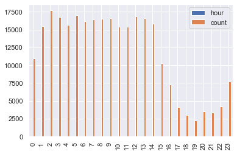

```python
grp = df_time_hour.groupBy('hour').count().sort('hour',ascending=False)
grp.toPandas().plot.bar()
```

## Bucketizing Numerical Features

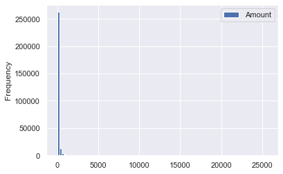

```python
df.select('Amount').toPandas().plot.hist(bins=100)
```

```python
df.select('Amount').describe().show()
```

```
+-------+-----------------+
|summary|           Amount|
+-------+-----------------+
|  count|           284807|
|   mean| 88.3496192509521|
| stddev|250.1201092401885|
|    min|              0.0|
|    max|         25691.16|
+-------+-----------------+
```

```python
# there is no easy way to get max or min in pyspark
amt_min = df.agg({"Amount": "min"}).collect()[0][0]
amt_max = df.agg({"Amount": "max"}).collect()[0][0]

amt_min, amt_max
```

```
(0.0, 25691.16)
```

```python
splits = np.linspace(amt_min, amt_max+1, 10)
splits
```

```
array([    0.        ,  2854.68444444,  5709.36888889,  8564.05333333,
       11418.73777778, 14273.42222222, 17128.10666667, 19982.79111111,
       22837.47555556, 25692.16      ])
```

```python
from pyspark.ml.feature import Bucketizer

bucketizer = Bucketizer(splits=splits,inputCol="Amount", outputCol="Amount_cat")

df = bucketizer.setHandleInvalid("keep").transform(df)

df.select('Amount','Amount_cat').show(5)
```

```
+------+----------+
|Amount|Amount_cat|
+------+----------+
|149.62|       0.0|
|  2.69|       0.0|
|378.66|       0.0|
| 123.5|       0.0|
| 69.99|       0.0|
+------+----------+
only showing top 5 rows
```

## Dummy Variables for Binned and Categorical Features

```python
cols_cat = ['Amount_cat']

indexers = [StringIndexer(inputCol=column, outputCol=column+"_index")
            for column in cols_cat]

encoder = OneHotEncoderEstimator(
    inputCols=[indexer.getOutputCol() for indexer in indexers],
    outputCols=["{0}_encoded".format(indexer.getOutputCol()) for indexer in indexers]
)

assembler = VectorAssembler(
    inputCols=encoder.getOutputCols(),
    outputCol="Amount_cat_vec"
)

pipeline = Pipeline(stages=indexers + [encoder, assembler])
df = pipeline.fit(df).transform(df)

df.printSchema()
```

```
root
 |-- Time: decimal(10,0) (nullable = true)
 |-- V1: double (nullable = true)
 |-- V2: double (nullable = true)
 |-- V3: double (nullable = true)
 |-- V4: double (nullable = true)
 |-- V5: double (nullable = true)
 |-- V6: double (nullable = true)
 |-- V7: double (nullable = true)
 |-- V8: double (nullable = true)
 |-- V9: double (nullable = true)
 |-- V10: double (nullable = true)
 |-- V11: double (nullable = true)
 |-- V12: double (nullable = true)
 |-- V13: double (nullable = true)
 |-- V14: double (nullable = true)
 |-- V15: double (nullable = true)
 |-- V16: double (nullable = true)
 |-- V17: double (nullable = true)
 |-- V18: double (nullable = true)
 |-- V19: double (nullable = true)
 |-- V20: double (nullable = true)
 |-- V21: double (nullable = true)
 |-- V22: double (nullable = true)
 |-- V23: double (nullable = true)
 |-- V24: double (nullable = true)
 |-- V25: double (nullable = true)
 |-- V26: double (nullable = true)
 |-- V27: double (nullable = true)
 |-- V28: double (nullable = true)
 |-- Amount: double (nullable = true)
 |-- Class: integer (nullable = true)
 |-- Amount_cat: double (nullable = true)
 |-- Amount_cat_index: double (nullable = false)
 |-- Amount_cat_index_encoded: vector (nullable = true)
 |-- Amount_cat_vec: vector (nullable = true)
```

```python
feat = 'Amount'
df.select(feat,f'{feat}_cat',f'{feat}_cat_index',f'{feat}_cat_index_encoded').show(5)
```

```
+------+----------+----------------+------------------------+
|Amount|Amount_cat|Amount_cat_index|Amount_cat_index_encoded|
+------+----------+----------------+------------------------+
|149.62|       0.0|             0.0|           (6,[0],[1.0])|
|  2.69|       0.0|             0.0|           (6,[0],[1.0])|
|378.66|       0.0|             0.0|           (6,[0],[1.0])|
| 123.5|       0.0|             0.0|           (6,[0],[1.0])|
| 69.99|       0.0|             0.0|           (6,[0],[1.0])|
+------+----------+----------------+------------------------+
only showing top 5 rows
```

## Log Transform Large Numerical Features

We generally perform log or boxcox transformation of features with large number to make it look like more Gaussian.

```python
df.select('Amount').withColumn('log1p_Amount', F.log1p("Amount")).show(2)
```

```
+------+------------------+
|Amount|      log1p_Amount|
+------+------------------+
|149.62| 5.014760108673205|
|  2.69|1.3056264580524357|
+------+------------------+
only showing top 2 rows
```

```python
np.log1p(149.62)
```

```
5.014760108673205
```

```python
cols_log = ['Time', 'Amount']

for c in cols_log:
    df = df.withColumn('log1p_' + c , F.log1p(c))
```

```python
print(df.columns)
```

```
['Time', 'V1', 'V2', 'V3', 'V4', 'V5', 'V6', 'V7', 'V8', 'V9', 'V10', 'V11', 'V12', 'V13', 'V14', 'V15', 'V16', 'V17', 'V18', 'V19', 'V20', 'V21', 'V22', 'V23', 'V24', 'V25', 'V26', 'V27', 'V28', 'Amount', 'Class', 'Amount_cat', 'Amount_cat_index', 'Amount_cat_index_encoded', 'Amount_cat_vec', 'log1…
```

```python
df.select(['log1p_Time', 'log1p_Amount']).show(2)
```

```
+----------+------------------+
|log1p_Time|      log1p_Amount|
+----------+------------------+
|       0.0| 5.014760108673205|
|       0.0|1.3056264580524357|
+----------+------------------+
only showing top 2 rows
```

```python
cols_after_log = ['log1p_' + i for i in cols_log]
cols_after_log
```

```
['log1p_Time', 'log1p_Amount']
```

## Combine All Features to One Column

```python
print(df.columns)
```

```
['Time', 'V1', 'V2', 'V3', 'V4', 'V5', 'V6', 'V7', 'V8', 'V9', 'V10', 'V11', 'V12', 'V13', 'V14', 'V15', 'V16', 'V17', 'V18', 'V19', 'V20', 'V21', 'V22', 'V23', 'V24', 'V25', 'V26', 'V27', 'V28', 'Amount', 'Class', 'Amount_cat', 'Amount_cat_index', 'Amount_cat_index_encoded', 'Amount_cat_vec', 'log1…
```

```python
selected_features = [ 'V1', 'V2', 'V3', 'V4', 'V5', 'V6', 'V7', 'V8', 'V9',
                     'V10', 'V11', 'V12', 'V13', 'V14', 'V15', 'V16', 'V17',
                     'V18', 'V19', 'V20', 'V21', 'V22', 'V23', 'V24', 'V25',
                     'V26', 'V27', 'V28',
                     'log1p_Time', 'log1p_Amount']
```

```python
assembler = VectorAssembler(
    inputCols= selected_features,
    outputCol='features'
)

df = assembler.transform(df)

df.printSchema()
```

```
root
 |-- Time: decimal(10,0) (nullable = true)
 |-- V1: double (nullable = true)
 |-- V2: double (nullable = true)
 |-- V3: double (nullable = true)
 |-- V4: double (nullable = true)
 |-- V5: double (nullable = true)
 |-- V6: double (nullable = true)
 |-- V7: double (nullable = true)
 |-- V8: double (nullable = true)
 |-- V9: double (nullable = true)
 |-- V10: double (nullable = true)
 |-- V11: double (nullable = true)
 |-- V12: double (nullable = true)
 |-- V13: double (nullable = true)
 |-- V14: double (nullable = true)
 |-- V15: double (nullable = true)
 |-- V16: double (nullable = true)
 |-- V17: double (nullable = true)
 |-- V18: double (nullable = true)
 |-- V19: double (nullable = true)
 |-- V20: double (nullable = true)
 |-- V21: double (nullable = true)
 |-- V22: double (nullable = true)
 |-- V23: double (nullable = true)
 |-- V24: double (nullable = true)
 |-- V25: double (nullable = true)
 |-- V26: double (nullable = true)
 |-- V27: double (nullable = true)
 |-- V28: double (nullable = true)
 |-- Amount: double (nullable = true)
 |-- Class: integer (nullable = true)
 |-- Amount_cat: double (nullable = true)
 |-- Amount_cat_index: double (nullable = false)
 |-- Amount_cat_index_encoded: vector (nullable = true)
 |-- Amount_cat_vec: vector (nullable = true)
 |-- log1p_Time: double (nullable = true)
 |-- log1p_Amount: double (nullable = true)
 |-- features: vector (nullable = true)
```

# Feature Scaling

```python
from pyspark.ml.feature import StandardScaler

scaler = StandardScaler(inputCol='features', outputCol='features_scaled')
df = scaler.fit(df).transform(df)

df.select(["features","features_scaled"]).limit(2).toPandas()
```

|  | features | features_scaled |
| --- | --- | --- |
| 0 | [-1.3598071336738, -0.0727811733098497, 2.5363... | [-0.6942411021638845, -0.04407484719355172, 1.... |
| 1 | [1.19185711131486, 0.26615071205963, 0.1664801... | [0.6084952594310945, 0.16117563692663966, 0.10... |

# Train Test Splitting

```python
train, test = df.randomSplit([0.8,0.2], seed=random_state)
train.count(), test.count()
```

```
(227519, 57288)
```

# Modelling

## Logistic Regression

```python
from pyspark.ml.classification import LogisticRegression

clf_lr = LogisticRegression(featuresCol='features_scaled',
                      labelCol='Class',
                     predictionCol='prediction',
                     maxIter=10).fit(train)
```

### Model Evaluation

```python
show_method_attributes(clf_lr,7)
```

|  | 0 | 1 | 2 | 3 | 4 | 5 | 6 |
| --- | --- | --- | --- | --- | --- | --- | --- |
| 0 | aggregationDepth | explainParams | hasDefault | labelCol | params | set | transform |
| 1 | coefficientMatrix | extractParamMap | hasParam | load | predictionCol | standardization | uid |
| 2 | coefficients | family | hasSummary | lowerBoundsOnCoefficients | probabilityCol | summary | upperBoundsOnCoefficients |
| 3 | copy | featuresCol | intercept | lowerBoundsOnIntercepts | rawPredictionCol | threshold | upperBoundsOnIntercepts |
| 4 | elasticNetParam | fitIntercept | interceptVector | maxIter | read | thresholds | weightCol |
| 5 | evaluate | getOrDefault | isDefined | numClasses | regParam | tol | write |
| 6 | explainParam | getParam | isSet | numFeatures | save |  |  |

### Predictions

```python
results_lr = clf_lr.transform(test)
preds_lr = results_lr.select('prediction')
preds_lr.groupBy('prediction').count().show()
```

```
+----------+-----+
|prediction|count|
+----------+-----+
|       0.0|57215|
|       1.0|   73|
+----------+-----+
```

### Model Evaluation Using ml.evaluation

https://spark.apache.org/docs/latest/api/python/_modules/pyspark/ml/evaluation.html

```
Binary Evualuator metrics: areaUnderROC|areaUnderPR
Multiclass Evaluator metrics: f1|weightedPrecision|weightedRecall|accuracy
```

```python
from pyspark.ml.evaluation import BinaryClassificationEvaluator
from pyspark.ml.evaluation import MulticlassClassificationEvaluator
from pyspark.ml.evaluation import ClusteringEvaluator
```

```python
def get_classification_eval_metrics(results,label_col,pred_col='prediction'):
    """Get Classification Evaluation Metrics for PySpark Modelling.

    """
    from pyspark.ml.evaluation import BinaryClassificationEvaluator
    from pyspark.ml.evaluation import MulticlassClassificationEvaluator

    # binary classification
    bc_metrics = ['areaUnderROC', 'areaUnderPR']
    bc_metrics_values = [BinaryClassificationEvaluator(
        rawPredictionCol=pred_col,
        labelCol=label_col,
        metricName=m).evaluate(results)
            for m in bc_metrics ]

    bc_df_metrics = pd.DataFrame({'metric': bc_metrics,
                                  'value': bc_metrics_values})


    # multiclass classification
    mc_metrics = ['f1', 'weightedPrecision', 'weightedRecall', 'accuracy']
    mc_metrics_values = [ MulticlassClassificationEvaluator(
        predictionCol=pred_col,
        labelCol=label_col,
        metricName=m).evaluate(results)
            for m in mc_metrics ]

    mc_df_metrics = pd.DataFrame({'metric': mc_metrics,
                                  'value': mc_metrics_values})

    # combine two dataframes
    df_metrics = bc_df_metrics.append(mc_df_metrics).set_index('metric')
    return df_metrics
```

```python
dfe = get_classification_eval_metrics(results_lr,'Class',pred_col='prediction')
row = dfe.values.ravel().tolist()
df_eval.loc[len(df_eval)] = ['Logistic Regression','log features'] + row
df_eval.drop_duplicates().sort_values('weightedRecall')
```

[output not shown]

```
Evaluator for Clustering results  expects
two input columns: prediction and features.

The metric computes the Silhouette measure using the squared Euclidean distance.

The Silhouette is a measure for the validation of the consistency
within clusters. It ranges between 1 and -1, where a value close to
1 means that the points in a cluster are close to the other points
in the same cluster and far from the points of the other clusters.
```

```python
from pyspark.ml.clustering import KMeans
from pyspark.ml.evaluation import ClusteringEvaluator
```

```python
clf_knn = KMeans(featuresCol='features_scaled',
                 #labelCol='Class', # labelCol does not exist for KMeans
                 seed=random_state,
                 predictionCol='prediction',
                 k=2).fit(train)
```

```python
results_knn = clf_knn.transform(test)
preds_knn = results_knn.select('prediction')
preds_knn.groupBy('prediction').count().show()
```

```
+----------+-----+
|prediction|count|
+----------+-----+
|         1|53836|
|         0| 3452|
+----------+-----+
```

```python
cluster_eval = ClusteringEvaluator(featuresCol='features_scaled',
                 #labelCol='Class', # label col does not exist for KNN
                 predictionCol='prediction',
                 distanceMeasure="squaredEuclidean",
                 metricName="silhouette")
```

```python
cluster_eval.evaluate(results_knn)
```

```
0.16745838107517577
```

## Decision Tree Classifier

```python
from pyspark.ml.classification import DecisionTreeClassifier
```

```python
clf_dt = DecisionTreeClassifier(featuresCol='features_scaled',
                 labelCol='Class',
                 seed=random_state,
                 predictionCol='prediction',
                 ).fit(train)
```

```python
show_method_attributes(clf_dt)
```

|  | 0 | 1 | 2 | 3 | 4 | 5 | 6 |
| --- | --- | --- | --- | --- | --- | --- | --- |
| 0 | cacheNodeIds | extractParamMap | hasParam | maxBins | numFeatures | rawPredictionCol | thresholds |
| 1 | checkpointInterval | featureImportances | impurity | maxDepth | numNodes | read | toDebugString |
| 2 | copy | featuresCol | isDefined | maxMemoryInMB | params | save | transform |
| 3 | depth | getOrDefault | isSet | minInfoGain | predictionCol | seed | uid |
| 4 | explainParam | getParam | labelCol | minInstancesPerNode | probabilityCol | set | write |
| 5 | explainParams | hasDefault | load | numClasses |  |  |  |

```python
results_dt = clf_dt.transform(test)
preds_dt = results_dt.select('prediction')
preds_dt.groupBy('prediction').count().show()
```

```
+----------+-----+
|prediction|count|
+----------+-----+
|       0.0|57212|
|       1.0|   76|
+----------+-----+
```

```python
dfe = get_classification_eval_metrics(results_dt,'Class',pred_col='prediction')
row = dfe.values.ravel().tolist()
df_eval.loc[len(df_eval)] = ['Decision Tree Classifier','log features'] + row
df_eval.drop_duplicates().sort_values('weightedRecall')
```

|  | model_name | desc | f1 | weightedPrecision | weightedRecall | accuracy | areaUnderROC | areaUnderPR |
| --- | --- | --- | --- | --- | --- | --- | --- | --- |
| 0 | Logistic Regression | log features | 0.846066 | 0.730487 | 0.999300 | 0.999294 | 0.999337 | 0.999337 |
| 3 | Decision Tree Classifier | log features | 0.868053 | 0.765536 | 0.999398 | 0.999393 | 0.999424 | 0.999424 |

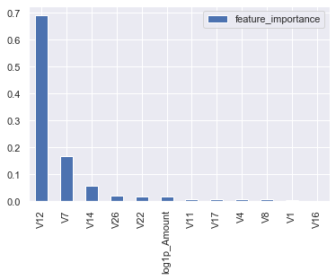

```python
df_feature_imp = pd.DataFrame(clf_dt.featureImportances.toArray(),
                          columns=['feature_importance'],
                          index=selected_features)

df_feature_imp.loc[lambda x: x['feature_importance'] >0]\
.sort_values('feature_importance',ascending=False)\
.plot.bar()
```

## Random Forest Classifier

```python
from pyspark.ml.classification import RandomForestClassifier
```

```python
clf_rfc = RandomForestClassifier(featuresCol='features_scaled',
                 labelCol='Class',
                 seed=random_state,
                 predictionCol='prediction',
                 ).fit(train)
```

```python
show_method_attributes(clf_rfc)
```

|  | 0 | 1 | 2 | 3 | 4 | 5 | 6 |
| --- | --- | --- | --- | --- | --- | --- | --- |
| 0 | cacheNodeIds | featureSubsetStrategy | impurity | maxDepth | numTrees | save | totalNumNodes |
| 1 | checkpointInterval | featuresCol | isDefined | maxMemoryInMB | params | seed | transform |
| 2 | copy | getNumTrees | isSet | minInfoGain | predictionCol | set | treeWeights |
| 3 | explainParam | getOrDefault | labelCol | minInstancesPerNode | probabilityCol | subsamplingRate | trees |
| 4 | explainParams | getParam | load | numClasses | rawPredictionCol | thresholds | uid |
| 5 | extractParamMap | hasDefault | maxBins | numFeatures | read | toDebugString | write |
| 6 | featureImportances | hasParam |  |  |  |  |  |

```python
results_rfc = clf_rfc.transform(test)
preds_rfc = results_rfc.select('prediction')
preds_rfc.groupBy('prediction').count().show()
```

```
+----------+-----+
|prediction|count|
+----------+-----+
|       0.0|57209|
|       1.0|   79|
+----------+-----+
```

```python
dfe = get_classification_eval_metrics(results_rfc,'Class',pred_col='prediction')
row = dfe.values.ravel().tolist()
df_eval.loc[len(df_eval)] = ['Random Forest Classifier','log features'] + row
df_eval.drop_duplicates().sort_values('weightedRecall')
```

|  | model_name | desc | f1 | weightedPrecision | weightedRecall | accuracy | areaUnderROC | areaUnderPR |
| --- | --- | --- | --- | --- | --- | --- | --- | --- |
| 0 | Logistic Regression | log features | 0.846066 | 0.730487 | 0.999300 | 0.999294 | 0.999337 | 0.999337 |
| 3 | Decision Tree Classifier | log features | 0.868053 | 0.765536 | 0.999398 | 0.999393 | 0.999424 | 0.999424 |
| 4 | Random Forest Classifier | log features | 0.890040 | 0.800147 | 0.999494 | 0.999490 | 0.999511 | 0.999511 |

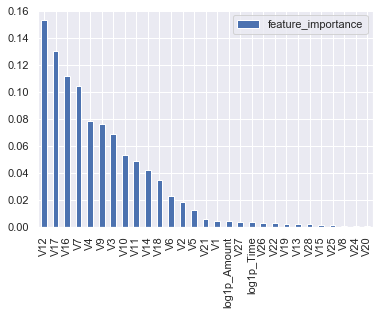

```python
df_feature_imp = pd.DataFrame(clf_rfc.featureImportances.toArray(),
                          columns=['feature_importance'],
                          index=selected_features)

df_feature_imp.loc[lambda x: x['feature_importance'] >0]\
.sort_values('feature_importance',ascending=False)\
.plot.bar()
```

# Parameter Tuning

```python
print(train.columns)
```

```
['Time', 'V1', 'V2', 'V3', 'V4', 'V5', 'V6', 'V7', 'V8', 'V9', 'V10', 'V11', 'V12', 'V13', 'V14', 'V15', 'V16', 'V17', 'V18', 'V19', 'V20', 'V21', 'V22', 'V23', 'V24', 'V25', 'V26', 'V27', 'V28', 'Amount', 'Class', 'Amount_cat', 'Amount_cat_index', 'Amount_cat_index_encoded', 'Amount_cat_vec', 'log1…
```

```python
print(selected_features)
```

```
['V1', 'V2', 'V3', 'V4', 'V5', 'V6', 'V7', 'V8', 'V9', 'V10', 'V11', 'V12', 'V13', 'V14', 'V15', 'V16', 'V17', 'V18', 'V19', 'V20', 'V21', 'V22', 'V23', 'V24', 'V25', 'V26', 'V27', 'V28', 'log1p_Time', 'log1p_Amount']
```

```python
from pyspark.ml import Pipeline
from pyspark.ml.tuning import ParamGridBuilder
from pyspark.ml.tuning import CrossValidator
import time

t0 = time.time()

clf_rfc = RandomForestClassifier(featuresCol='features_scaled',
                                 labelCol = "Class",
                                 numTrees = 50,
                                 seed=random_state)

grid_depths = [10,20]
paramGrid = ParamGridBuilder()\
   .addGrid(clf_rfc.maxDepth, grid_depths)\
   .addGrid(clf_rfc.minInstancesPerNode, grid_depths)\
   .build()

pipeline = Pipeline(stages = [clf_rfc])

evaluator = MulticlassClassificationEvaluator(labelCol = "Class",
                                              metricName = "weightedRecall")

crossval = CrossValidator(estimator = pipeline,
                          estimatorParamMaps = paramGrid,
                          evaluator = evaluator,
                          seed = random_state,
                          parallelism=50, # number of threads to use
                          numFolds = 5)


# model_cv = crossval.fit(train)

t1 = time.time() - t0
print('Time taken: {:.0f} min {:.0f} secs'.format(*divmod(t1,60)))
# Time taken: Time taken: 8 min 16 secs
```

[output not shown]

[output not shown]

```python
show_method_attributes(model_cv,7)
```

|  | 0 | 1 | 2 | 3 | 4 | 5 | 6 |
| --- | --- | --- | --- | --- | --- | --- | --- |
| 0 | avgMetrics | evaluator | getEstimatorParamMaps | hasDefault | params | setEstimator | subModels |
| 1 | bestModel | explainParam | getEvaluator | hasParam | read | setEstimatorParamMaps | transform |
| 2 | copy | explainParams | getOrDefault | isDefined | save | setEvaluator | uid |
| 3 | estimator | extractParamMap | getParam | isSet | seed | setSeed | write |
| 4 | estimatorParamMaps | getEstimator | getSeed | load | set |  |  |

```python
# model_cv.save('../models/serialization/pyspark_clf_rfc_grid_search.pkl')
# AttributeError: 'Pipeline' object has no attribute '_transfer_param_map_to_java'
```

```python
results_rfc_grid = model_cv.transform(test)
```

```python
print(results_rfc_grid.columns)
```

```
['Time', 'V1', 'V2', 'V3', 'V4', 'V5', 'V6', 'V7', 'V8', 'V9', 'V10', 'V11', 'V12', 'V13', 'V14', 'V15', 'V16', 'V17', 'V18', 'V19', 'V20', 'V21', 'V22', 'V23', 'V24', 'V25', 'V26', 'V27', 'V28', 'Amount', 'Class', 'Amount_cat', 'Amount_cat_index', 'Amount_cat_index_encoded', 'Amount_cat_vec', 'log1…
```

```python
evaluator.evaluate(results_rfc_grid)
```

```
0.9995636084345761
```

```python
model_cv.bestModel.stages
```

```
[RandomForestClassificationModel (uid=RandomForestClassifier_dae08062b786) with 50 trees]
```

```python
model_cv.params
```

```
[Param(parent='CrossValidatorModel_e443802db3db', name='estimator', doc='estimator to be cross-validated'),
 Param(parent='CrossValidatorModel_e443802db3db', name='estimatorParamMaps', doc='estimator param maps'),
 Param(parent='CrossValidatorModel_e443802db3db', name='evaluator', doc='evaluator used to select hyper-parameters that maximize the validator metric'),
 Param(parent='CrossValidatorModel_e443802db3db', name='seed', doc='random seed.')]
```

```python
dfe = get_classification_eval_metrics(results_rfc_grid,'Class',pred_col='prediction')
row = dfe.values.ravel().tolist()
df_eval.loc[len(df_eval)] = ['Random Forest Classifier','log features, grid search'] + row
df_eval.drop_duplicates().sort_values('weightedRecall')
```

|  | model_name | desc | f1 | weightedPrecision | weightedRecall | accuracy | areaUnderROC | areaUnderPR |
| --- | --- | --- | --- | --- | --- | --- | --- | --- |
| 0 | Logistic Regression | log features | 0.846066 | 0.730487 | 0.999300 | 0.999294 | 0.999337 | 0.999337 |
| 3 | Decision Tree Classifier | log features | 0.868053 | 0.765536 | 0.999398 | 0.999393 | 0.999424 | 0.999424 |
| 4 | Random Forest Classifier | log features | 0.890040 | 0.800147 | 0.999494 | 0.999490 | 0.999511 | 0.999511 |
| 6 | Random Forest Classifier | log features, grid search | 0.884580 | 0.836982 | 0.999541 | 0.999548 | 0.999564 | 0.999564 |

# Feature Importances

```python
model_cv.bestModel.stages[-1].featureImportances
```

```
SparseVector(30, {0: 0.0022, 1: 0.0085, 2: 0.0628, 3: 0.0334, 4: 0.0116, 5: 0.0056, 6: 0.1099, 7: 0.0146, 8: 0.0774, 9: 0.0748, 10: 0.0384, 11: 0.1133, 12: 0.0055, 13: 0.0883, 14: 0.008, 15: 0.0818, 16: 0.1451, 17: 0.0257, 18: 0.0024, 19: 0.0077, 20: 0.0058, 21: 0.0085, 22: 0.0058, 23: 0.0087, 24: 0…
```

```python
prediction.schema["features"].metadata["ml_attr"]["attrs"]
```

```
{'numeric': [{'idx': 0, 'name': 'V1'},
  {'idx': 1, 'name': 'V2'},
  {'idx': 2, 'name': 'V3'},
  {'idx': 3, 'name': 'V4'},
  {'idx': 4, 'name': 'V5'},
  {'idx': 5, 'name': 'V6'},
  {'idx': 6, 'name': 'V7'},
  {'idx': 7, 'name': 'V8'},
  {'idx': 8, 'name': 'V9'},
  {'idx': 9, 'name': 'V10'},
  {'idx': 10, 'name': 'V11'},
  {'idx': 11, 'name': 'V12'},
  {'idx': 12, 'name': 'V13'},
  {'idx': 13, 'name': 'V14'},
  {'idx': 14, 'name': 'V15'},
  {'idx': 15, 'name': 'V16'},
  {'idx': 16, 'name': 'V17'},
  {'idx': 17, 'name': 'V18'},
  {'idx': 18, 'name': 'V19'},
  {'idx': 19, 'name': 'V20'},
  {'idx': 20, 'name': 'V21'},
  {'idx': 21, 'name': 'V22'},
  {'idx': 22, 'name': 'V23'},
  {'idx': 23, 'name': 'V24'},
  {'idx': 24, 'name': 'V25'},
  {'idx': 25, 'name': 'V26'},
  {'idx': 26, 'name': 'V27'},
  {'idx': 27, 'name': 'V28'},
  {'idx': 28, 'name': 'log1p_Time'},
  {'idx': 29, 'name': 'log1p_Amount'}]}
```

```python
# https://stackoverflow.com/questions/42935914/how-to-map-features-from-the-output-of-a-vectorassembler-back-to-the-column-name
def get_feature_importance_df(model_cv, dataset, featuresCol):
    feat_imp = model_cv.bestModel.stages[-1].featureImportances
    list_extract = []
    for i in dataset.schema[featuresCol].metadata["ml_attr"]["attrs"]:
        list_extract += dataset.schema[featuresCol].metadata["ml_attr"]["attrs"][i]

    pandas_df_feat_imp = pd.DataFrame(list_extract)
    pandas_df_feat_imp['importance'] = pandas_df_feat_imp['idx'].apply(lambda x: feat_imp[x])
    pandas_df_feat_imp = pandas_df_feat_imp.sort_values('importance', ascending = False)

    return pandas_df_feat_imp
```

```python
pandas_df_feat_imp = get_feature_importance_df(model_cv, prediction, "features")
pandas_df_feat_imp.style.background_gradient(subset=['importance'])
```

|  | idx | name | importance |
| --- | --- | --- | --- |
| 16 | 16 | V17 | 0.1451 |
| 11 | 11 | V12 | 0.1133 |
| 6 | 6 | V7 | 0.109919 |
| 13 | 13 | V14 | 0.088303 |
| 15 | 15 | V16 | 0.0818398 |
| 8 | 8 | V9 | 0.0773547 |
| 9 | 9 | V10 | 0.0747522 |
| 2 | 2 | V3 | 0.0628027 |
| 10 | 10 | V11 | 0.0383619 |
| 3 | 3 | V4 | 0.0334011 |
| 17 | 17 | V18 | 0.0256938 |
| 7 | 7 | V8 | 0.0145529 |
| 25 | 25 | V26 | 0.0145493 |
| 28 | 28 | log1p_Time | 0.0121996 |
| 29 | 29 | log1p_Amount | 0.0120428 |
| 4 | 4 | V5 | 0.0115613 |
| 23 | 23 | V24 | 0.00865824 |
| 1 | 1 | V2 | 0.00851461 |
| 21 | 21 | V22 | 0.00848692 |
| 14 | 14 | V15 | 0.00796113 |
| 19 | 19 | V20 | 0.00774602 |
| 27 | 27 | V28 | 0.00773218 |
| 26 | 26 | V27 | 0.00596056 |
| 20 | 20 | V21 | 0.00583038 |
| 22 | 22 | V23 | 0.00577398 |
| 5 | 5 | V6 | 0.00555172 |
| 12 | 12 | V13 | 0.00552945 |
| 18 | 18 | V19 | 0.00241755 |
| 0 | 0 | V1 | 0.00218484 |
| 24 | 24 | V25 | 0.00191832 |

# Confusion Matrix

```python
results_rfc.select('prediction','Class').show(5)
```

```
+----------+-----+
|prediction|Class|
+----------+-----+
|       0.0|    0|
|       0.0|    0|
|       0.0|    0|
|       0.0|    0|
|       0.0|    0|
+----------+-----+
only showing top 5 rows
```

```python
def pyspark_confusion_matrix(model_name, results,
                             label_col='Class',pred_col='prediction'):

    tp = results[(results[label_col] == 1) & (results[pred_col] == 1.0)].count()
    tn = results[(results[label_col] == 0) & (results[pred_col] == 0.0)].count()
    fp = results[(results[label_col] == 0) & (results[pred_col] == 1.0)].count()
    fn = results[(results[label_col] == 1) & (results[pred_col] == 0.0)].count()

    total = tp + tn + fp + fn

    recall = float(tp)/(tp + fn)
    precision = float(tp) / (tp + fp)

    print('Model name     : ', model_name)
    print("True Positive  : ", tp)
    print("True Negatives : ", tn)
    print()
    print("False Positives: ", fp)
    print("False Negatives: ", fn)
    print()
    print("Total          : ", total)
    print("Precison       : ", round(precision,3))
    print("Recall         : ", round(recall,3))

pyspark_confusion_matrix('Random Forest, grid search', results_rfc_grid)
```

```
Model name     :  Random Forest, grid search
True Positive  :  70
True Negatives :  57193

False Positives:  4
False Negatives:  21

Total          :  57288
Precison       :  0.946
Recall         :  0.769
```

```python
cm = np.array([[tn,fp],
               [fn,tp]
              ])
cm
```

[output not shown]

```python
from sklearn.metrics import confusion_matrix

original_ytest = results_rfc.select('Class').toPandas().values
y_preds = results_rfc.select('prediction').toPandas().values.astype(int)

confusion_matrix(original_ytest,y_preds)
```

```
array([[57189,     8],
       [   20,    71]])
```

```python
# help(confusion_matrix)
```